# Practical Machine Learning Course Project

M

January 13, 2017

## Introduction

This project is a part of the Practical Machine Learning Course by John Hopkins University on Coursera.

## Executive Summary

Using devices such as Jawbone Up, Nike FuelBand, and Fitbit it is now possible to collect a large amount of data about personal activity relatively inexpensively. These type of devices are part of the quantified self movement - a group of enthusiasts who take measurements about themselves regularly to improve their health, to find patterns in their behavior, or because they are tech geeks. One thing that people regularly do is quantify how much of a particular activity they do, but they rarely quantify how well they do it. In this project, the goal is to use data from accelerometers on the belt, forearm, arm, and dumbell of 6 participants. They were asked to perform barbell lifts correctly and incorrectly in 5 different ways. More information is available from the website here: http://groupware.les.inf.puc-rio.br/har.

## Analysis

```r
library(caret)
```

```r
library(rpart)
library(rpart.plot)
library(rattle)
library(randomForest)
library(plyr)
library(survival)
library(splines)
library(parallel)
library(gbm)
```

### Download and Clean the Data

```r
training <- read.csv("pml-training.csv", header=TRUE, na.strings=c("NA", "", "#DIV/0!"))
testing <- read.csv("pml-testing.csv", header=TRUE, na.strings=c("NA", "", "#DIV/0!"))
# Converting the values into numeric
for(i in c(8:ncol(training)-1)){
  training[,i]= as.numeric(as.character(training[,i]))
  testing[,i]= as.numeric(as.character(testing[,i]))
}
training[is.na(training)] <-0 # Assigning 0 to all NAs
training <- training[-c(1:7)] # Removing first 7 columns

testing[is.na(testing)] <- 0
testing <- testing[-c(1:7)]
# Partitioning the Data
inTrain <- createDataPartition(training$classe, p=0.6, list=FALSE)
myTraining <- training[inTrain,]
myTesting <- training[-inTrain,]
```

## Fitting Models

### Model 1: Decision Tree

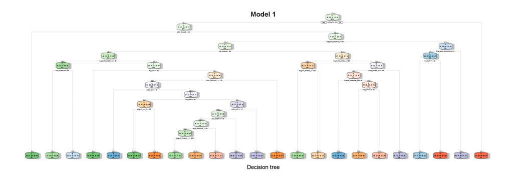

```r
mod_DT <- rpart(classe ~., method="class", data=myTraining)
fancyRpartPlot(mod_DT, main="Model 1", sub="Decision tree")
```

```r
pred_DT <- predict(mod_DT, myTesting, type="class")
confusionMatrix(pred_DT, myTesting$classe)
```

```
## Confusion Matrix and Statistics
##
##           Reference
## Prediction    A    B    C    D    E
##          A 1987  220   27   70   40
##          B   65  762   74   79   81
##          C   70  237 1142  183  184
##          D   69  115   95  831   74
##          E   41  184   30  123 1063
##
## Overall Statistics
##
##                Accuracy : 0.7373
##                  95% CI : (0.7274, 0.747)
##     No Information Rate : 0.2845
##     P-Value [Acc > NIR] : < 2.2e-16
##
##                   Kappa : 0.6675
##  Mcnemar's Test P-Value : < 2.2e-16
##
## Statistics by Class:
##
##                      Class: A Class: B Class: C Class: D Class: E
## Sensitivity            0.8902  0.50198   0.8348   0.6462   0.7372
## Specificity            0.9364  0.95275   0.8960   0.9462   0.9410
## Pos Pred Value         0.8477  0.71819   0.6289   0.7019   0.7377
## Neg Pred Value         0.9555  0.88858   0.9625   0.9317   0.9408
## Prevalence             0.2845  0.19347   0.1744   0.1639   0.1838
## Detection Rate         0.2533  0.09712   0.1456   0.1059   0.1355
## Detection Prevalence   0.2988  0.13523   0.2315   0.1509   0.1837
## Balanced Accuracy      0.9133  0.72736   0.8654   0.7962   0.8391
```

### Model 2: Random Forest

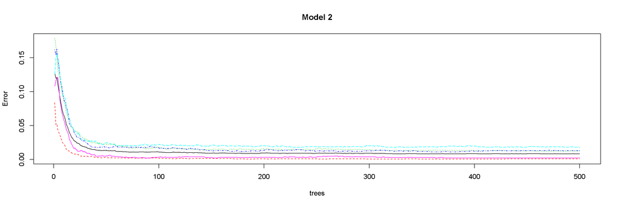

```r
mod_RF <- randomForest(classe ~ ., myTraining)
plot(mod_RF, main="Model 2")
```

```r
pred_RF <- predict(mod_RF, myTesting, type="class")
confusionMatrix(pred_RF, myTesting$classe)
```

```
## Confusion Matrix and Statistics
##
##           Reference
## Prediction    A    B    C    D    E
##          A 2227    7    0    0    0
##          B    5 1505   11    0    0
##          C    0    6 1353   16    0
##          D    0    0    4 1270    1
##          E    0    0    0    0 1441
##
## Overall Statistics
##
##                Accuracy : 0.9936
##                  95% CI : (0.9916, 0.9953)
##     No Information Rate : 0.2845
##     P-Value [Acc > NIR] : < 2.2e-16
##
##                   Kappa : 0.9919
##  Mcnemar's Test P-Value : NA
##
## Statistics by Class:
##
##                      Class: A Class: B Class: C Class: D Class: E
## Sensitivity            0.9978   0.9914   0.9890   0.9876   0.9993
## Specificity            0.9988   0.9975   0.9966   0.9992   1.0000
## Pos Pred Value         0.9969   0.9895   0.9840   0.9961   1.0000
## Neg Pred Value         0.9991   0.9979   0.9977   0.9976   0.9998
## Prevalence             0.2845   0.1935   0.1744   0.1639   0.1838
## Detection Rate         0.2838   0.1918   0.1724   0.1619   0.1837
## Detection Prevalence   0.2847   0.1939   0.1752   0.1625   0.1837
## Balanced Accuracy      0.9983   0.9945   0.9928   0.9934   0.9997
```

### Model 3: Generalized Boosted Regression

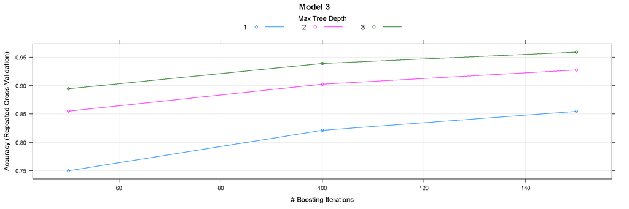

```r
set.seed(543)
fitControl <- trainControl(method = "repeatedcv",
                           number = 3,
                           repeats = 1)
mod_BR <- train(classe ~., myTraining, method="gbm", trControl=fitControl, verbose = FALSE)
plot(mod_BR, main="Model 3")
```

```r
mod_BR_final <- mod_BR$finalModel
pred_BR <- predict(mod_BR, myTesting)
confusionMatrix(pred_BR, myTesting$classe)
```

```
## Confusion Matrix and Statistics
##
##           Reference
## Prediction    A    B    C    D    E
##          A 2195   44    0    1    3
##          B   24 1423   52    3   18
##          C   10   49 1294   29   11
##          D    2    1   21 1242   10
##          E    1    1    1   11 1400
##
## Overall Statistics
##
##                Accuracy : 0.9628
##                  95% CI : (0.9584, 0.9669)
##     No Information Rate : 0.2845
##     P-Value [Acc > NIR] : < 2.2e-16
##
##                   Kappa : 0.9529
##  Mcnemar's Test P-Value : 4.625e-06
##
## Statistics by Class:
##
##                      Class: A Class: B Class: C Class: D Class: E
## Sensitivity            0.9834   0.9374   0.9459   0.9658   0.9709
## Specificity            0.9914   0.9847   0.9847   0.9948   0.9978
## Pos Pred Value         0.9786   0.9362   0.9289   0.9734   0.9901
## Neg Pred Value         0.9934   0.9850   0.9885   0.9933   0.9935
## Prevalence             0.2845   0.1935   0.1744   0.1639   0.1838
## Detection Rate         0.2798   0.1814   0.1649   0.1583   0.1784
## Detection Prevalence   0.2859   0.1937   0.1775   0.1626   0.1802
## Balanced Accuracy      0.9874   0.9610   0.9653   0.9803   0.9843
```

From the models, we can see that the Model 2 with Random Forest, has higher accuracy of 99%. Therefore, we will select Model 2 and apply the prediction on the “testing” data set.

```r
final_mod <- predict(mod_RF, testing)
final_mod
```

```
##  1  2  3  4  5  6  7  8  9 10 11 12 13 14 15 16 17 18 19 20
##  B  A  B  A  A  E  D  B  A  A  B  C  B  A  E  E  A  B  B  B
## Levels: A B C D E
```